# Optimal Treatment Analysis

## Outcome Variable

**Outcome Variable:** whz

## Predictor Variables

**Intervention Variable:** mbmi

**Adjustment Set:**

- arm
- W_mage
- meducyrs
- feducyrs
- single
- brthmon
- delta_W_mage
- delta_meducyrs
- delta_feducyrs
- delta_single
- delta_brthmon

## Stratifying Variables

The analysis was stratified on these variable(s):

- agecat
- studyid
- country

## Data Summary

| agecat | studyid | country | mbmi | n_cell | n |
| --- | --- | --- | --- | --- | --- |
| Birth | ki0047075b-MAL-ED | BANGLADESH | Normal weight | 205 | 233 |
| Birth | ki0047075b-MAL-ED | BANGLADESH | Underweight | 28 | 233 |
| Birth | ki0047075b-MAL-ED | BRAZIL | Normal weight | 167 | 176 |
| Birth | ki0047075b-MAL-ED | BRAZIL | Underweight | 9 | 176 |
| Birth | ki0047075b-MAL-ED | INDIA | Normal weight | 157 | 195 |
| Birth | ki0047075b-MAL-ED | INDIA | Underweight | 38 | 195 |
| Birth | ki0047075b-MAL-ED | NEPAL | Normal weight | 167 | 167 |
| Birth | ki0047075b-MAL-ED | NEPAL | Underweight | 0 | 167 |
| Birth | ki0047075b-MAL-ED | PERU | Normal weight | 264 | 269 |
| Birth | ki0047075b-MAL-ED | PERU | Underweight | 5 | 269 |
| Birth | ki0047075b-MAL-ED | SOUTH AFRICA | Normal weight | 221 | 226 |
| Birth | ki0047075b-MAL-ED | SOUTH AFRICA | Underweight | 5 | 226 |
| Birth | ki0047075b-MAL-ED | TANZANIA, UNITED REPUBLIC OF | Normal weight | 109 | 116 |
| Birth | ki0047075b-MAL-ED | TANZANIA, UNITED REPUBLIC OF | Underweight | 7 | 116 |
| Birth | ki1000304b-SAS-CompFeed | INDIA | Normal weight | 23 | 33 |
| Birth | ki1000304b-SAS-CompFeed | INDIA | Underweight | 10 | 33 |
| Birth | ki1017093-NIH-Birth | BANGLADESH | Normal weight | 23 | 28 |
| Birth | ki1017093-NIH-Birth | BANGLADESH | Underweight | 5 | 28 |
| Birth | ki1017093c-NIH-Crypto | BANGLADESH | Normal weight | 17 | 23 |
| Birth | ki1017093c-NIH-Crypto | BANGLADESH | Underweight | 6 | 23 |
| Birth | ki1119695-PROBIT | BELARUS | Normal weight | 6399 | 6652 |
| Birth | ki1119695-PROBIT | BELARUS | Underweight | 253 | 6652 |
| Birth | ki1126311-ZVITAMBO | ZIMBABWE | Normal weight | 8573 | 9029 |
| Birth | ki1126311-ZVITAMBO | ZIMBABWE | Underweight | 456 | 9029 |
| 6 months | ki0047075b-MAL-ED | BANGLADESH | Normal weight | 209 | 241 |
| 6 months | ki0047075b-MAL-ED | BANGLADESH | Underweight | 32 | 241 |
| 6 months | ki0047075b-MAL-ED | BRAZIL | Normal weight | 199 | 208 |
| 6 months | ki0047075b-MAL-ED | BRAZIL | Underweight | 9 | 208 |
| 6 months | ki0047075b-MAL-ED | INDIA | Normal weight | 186 | 235 |
| 6 months | ki0047075b-MAL-ED | INDIA | Underweight | 49 | 235 |

[output cut: 52 more lines]

The following strata were considered:

- agecat: 24 months, studyid: ki0047075b-MAL-ED, country: BANGLADESH
- agecat: 24 months, studyid: ki0047075b-MAL-ED, country: BRAZIL
- agecat: 24 months, studyid: ki0047075b-MAL-ED, country: INDIA
- agecat: 24 months, studyid: ki0047075b-MAL-ED, country: NEPAL
- agecat: 24 months, studyid: ki0047075b-MAL-ED, country: PERU
- agecat: 24 months, studyid: ki0047075b-MAL-ED, country: SOUTH AFRICA
- agecat: 24 months, studyid: ki0047075b-MAL-ED, country: TANZANIA, UNITED REPUBLIC OF
- agecat: 24 months, studyid: ki1017093-NIH-Birth, country: BANGLADESH
- agecat: 24 months, studyid: ki1017093b-PROVIDE, country: BANGLADESH
- agecat: 24 months, studyid: ki1017093c-NIH-Crypto, country: BANGLADESH
- agecat: 24 months, studyid: ki1066203-TanzaniaChild2, country: TANZANIA, UNITED REPUBLIC OF
- agecat: 24 months, studyid: ki1119695-PROBIT, country: BELARUS
- agecat: 24 months, studyid: ki1126311-ZVITAMBO, country: ZIMBABWE
- agecat: 24 months, studyid: ki1148112-LCNI-5, country: MALAWI
- agecat: 6 months, studyid: ki0047075b-MAL-ED, country: BANGLADESH
- agecat: 6 months, studyid: ki0047075b-MAL-ED, country: BRAZIL
- agecat: 6 months, studyid: ki0047075b-MAL-ED, country: INDIA
- agecat: 6 months, studyid: ki0047075b-MAL-ED, country: NEPAL
- agecat: 6 months, studyid: ki0047075b-MAL-ED, country: PERU
- agecat: 6 months, studyid: ki0047075b-MAL-ED, country: SOUTH AFRICA
- agecat: 6 months, studyid: ki0047075b-MAL-ED, country: TANZANIA, UNITED REPUBLIC OF
- agecat: 6 months, studyid: ki1000304b-SAS-CompFeed, country: INDIA
- agecat: 6 months, studyid: ki1017093-NIH-Birth, country: BANGLADESH
- agecat: 6 months, studyid: ki1017093b-PROVIDE, country: BANGLADESH
- agecat: 6 months, studyid: ki1017093c-NIH-Crypto, country: BANGLADESH
- agecat: 6 months, studyid: ki1066203-TanzaniaChild2, country: TANZANIA, UNITED REPUBLIC OF
- agecat: 6 months, studyid: ki1119695-PROBIT, country: BELARUS
- agecat: 6 months, studyid: ki1126311-ZVITAMBO, country: ZIMBABWE
- agecat: 6 months, studyid: ki1148112-LCNI-5, country: MALAWI
- agecat: Birth, studyid: ki0047075b-MAL-ED, country: BANGLADESH
- agecat: Birth, studyid: ki0047075b-MAL-ED, country: BRAZIL
- agecat: Birth, studyid: ki0047075b-MAL-ED, country: INDIA
- agecat: Birth, studyid: ki0047075b-MAL-ED, country: NEPAL
- agecat: Birth, studyid: ki0047075b-MAL-ED, country: PERU
- agecat: Birth, studyid: ki0047075b-MAL-ED, country: SOUTH AFRICA
- agecat: Birth, studyid: ki0047075b-MAL-ED, country: TANZANIA, UNITED REPUBLIC OF
- agecat: Birth, studyid: ki1000304b-SAS-CompFeed, country: INDIA
- agecat: Birth, studyid: ki1017093-NIH-Birth, country: BANGLADESH
- agecat: Birth, studyid: ki1017093c-NIH-Crypto, country: BANGLADESH
- agecat: Birth, studyid: ki1119695-PROBIT, country: BELARUS
- agecat: Birth, studyid: ki1126311-ZVITAMBO, country: ZIMBABWE

### Dropped Strata

Some strata were dropped due to rare outcomes:

- agecat: Birth, studyid: ki0047075b-MAL-ED, country: NEPAL
- agecat: 6 months, studyid: ki0047075b-MAL-ED, country: NEPAL
- agecat: 24 months, studyid: ki0047075b-MAL-ED, country: NEPAL
- agecat: 24 months, studyid: ki0047075b-MAL-ED, country: PERU
- agecat: 24 months, studyid: ki1066203-TanzaniaChild2, country: TANZANIA, UNITED REPUBLIC OF

## Methods Detail

We’re interested in the causal parameters $E[Y_a]$ for all values of $a \in \mathcal{A}$. These parameters represent the mean outcome if, possibly contrary to fact, we intervened to set all units to have $A=a$. Under the randomization and positivity assumptions, these are identified by the statistical parameters $\psi_a=E_W[E_{Y|A,W}(Y|A=a,W)]$. In addition, we’re interested in the mean of $Y$, $E[Y]$ under no intervention (the observed mean). We will estimate these parameters by using SuperLearner to fit the relevant likelihood factors – $E_{Y|A,W}(Y|A=a,W)$ and $p(A=a|W)$, and then updating our likelihood fit using a joint TMLE.

For unadjusted analyses ($W=\{\}$), initial likelihoods were estimated using Lrnr_glm to estimate the simple $E(Y|A)$ and Lrnr_mean to estimate $p(A)$. For adjusted analyses, a small library containing Lrnr_glmnet, Lrnr_xgboost, and Lrnr_mean was used.

Having estimated these parameters, we will then use the delta method to estimate relative risks and attributable risks relative to a prespecified baseline level of $A$.

# Results Detail

## Results Plots

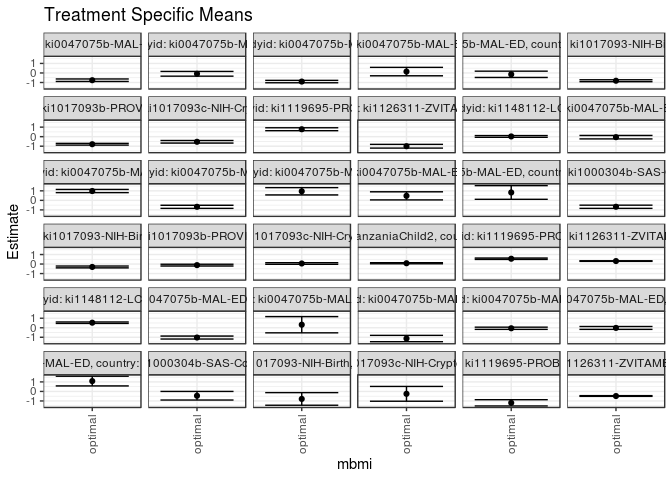

## Results Table

### Parameter: TSM

| agecat | studyid | country | intervention_level | baseline_level | estimate | ci_lower | ci_upper |
| --- | --- | --- | --- | --- | --- | --- | --- |
| Birth | ki0047075b-MAL-ED | BANGLADESH | optimal | observed | -1.0277559 | -1.1827990 | -0.8727127 |
| Birth | ki0047075b-MAL-ED | BRAZIL | optimal | observed | 0.3181545 | -0.5340381 | 1.1703472 |
| Birth | ki0047075b-MAL-ED | INDIA | optimal | observed | -1.1316785 | -1.4633104 | -0.8000466 |
| Birth | ki0047075b-MAL-ED | PERU | optimal | observed | -0.0543913 | -0.1690191 | 0.0602366 |
| Birth | ki0047075b-MAL-ED | SOUTH AFRICA | optimal | observed | -0.0179195 | -0.1686282 | 0.1327891 |
| Birth | ki0047075b-MAL-ED | TANZANIA, UNITED REPUBLIC OF | optimal | observed | 1.0860884 | 0.5783015 | 1.5938754 |
| Birth | ki1000304b-SAS-CompFeed | INDIA | optimal | observed | -0.4527210 | -0.9040528 | -0.0013893 |
| Birth | ki1017093-NIH-Birth | BANGLADESH | optimal | observed | -0.7860357 | -1.4477747 | -0.1242967 |
| Birth | ki1017093c-NIH-Crypto | BANGLADESH | optimal | observed | -0.2496722 | -1.0268612 | 0.5275169 |
| Birth | ki1119695-PROBIT | BELARUS | optimal | observed | -1.1958705 | -1.5260777 | -0.8656633 |
| Birth | ki1126311-ZVITAMBO | ZIMBABWE | optimal | observed | -0.4817650 | -0.5193168 | -0.4442133 |
| 6 months | ki0047075b-MAL-ED | BANGLADESH | optimal | observed | -0.0528281 | -0.2321556 | 0.1264994 |
| 6 months | ki0047075b-MAL-ED | BRAZIL | optimal | observed | 0.9776896 | 0.8091006 | 1.1462787 |
| 6 months | ki0047075b-MAL-ED | INDIA | optimal | observed | -0.6771137 | -0.8385573 | -0.5156702 |
| 6 months | ki0047075b-MAL-ED | PERU | optimal | observed | 0.9531785 | 0.5692482 | 1.3371087 |
| 6 months | ki0047075b-MAL-ED | SOUTH AFRICA | optimal | observed | 0.4736100 | 0.0487602 | 0.8984599 |
| 6 months | ki0047075b-MAL-ED | TANZANIA, UNITED REPUBLIC OF | optimal | observed | 0.8277857 | 0.1102405 | 1.5453309 |
| 6 months | ki1000304b-SAS-CompFeed | INDIA | optimal | observed | -0.6720742 | -0.8421245 | -0.5020238 |
| 6 months | ki1017093-NIH-Birth | BANGLADESH | optimal | observed | -0.3032666 | -0.3996495 | -0.2068836 |
| 6 months | ki1017093b-PROVIDE | BANGLADESH | optimal | observed | -0.1129265 | -0.2051708 | -0.0206822 |
| 6 months | ki1017093c-NIH-Crypto | BANGLADESH | optimal | observed | 0.0592631 | -0.0225654 | 0.1410916 |
| 6 months | ki1066203-TanzaniaChild2 | TANZANIA, UNITED REPUBLIC OF | optimal | observed | 0.0857519 | 0.0312161 | 0.1402878 |
| 6 months | ki1119695-PROBIT | BELARUS | optimal | observed | 0.5577781 | 0.4872947 | 0.6282616 |
| 6 months | ki1126311-ZVITAMBO | ZIMBABWE | optimal | observed | 0.3144596 | 0.2859080 | 0.3430111 |
| 6 months | ki1148112-LCNI-5 | MALAWI | optimal | observed | 0.5302361 | 0.4520566 | 0.6084157 |
| 24 months | ki0047075b-MAL-ED | BANGLADESH | optimal | observed | -0.7601665 | -0.8912902 | -0.6290428 |
| 24 months | ki0047075b-MAL-ED | BRAZIL | optimal | observed | -0.0869210 | -0.3374378 | 0.1635958 |
| 24 months | ki0047075b-MAL-ED | INDIA | optimal | observed | -0.9021238 | -1.0271713 | -0.7770763 |
| 24 months | ki0047075b-MAL-ED | SOUTH AFRICA | optimal | observed | 0.1454279 | -0.2973767 | 0.5882324 |
| 24 months | ki0047075b-MAL-ED | TANZANIA, UNITED REPUBLIC OF | optimal | observed | -0.1417551 | -0.4721004 | 0.1885902 |
| 24 months | ki1017093-NIH-Birth | BANGLADESH | optimal | observed | -0.8144224 | -0.9174861 | -0.7113588 |
| 24 months | ki1017093b-PROVIDE | BANGLADESH | optimal | observed | -0.7930481 | -0.8835615 | -0.7025346 |
| 24 months | ki1017093c-NIH-Crypto | BANGLADESH | optimal | observed | -0.5376115 | -0.6707390 | -0.4044840 |
| 24 months | ki1119695-PROBIT | BELARUS | optimal | observed | 0.7789975 | 0.6253497 | 0.9326453 |
| 24 months | ki1126311-ZVITAMBO | ZIMBABWE | optimal | observed | -1.0033958 | -1.1988049 | -0.8079868 |
| 24 months | ki1148112-LCNI-5 | MALAWI | optimal | observed | 0.0243030 | -0.0659686 | 0.1145747 |

### Parameter: E(Y)

| agecat | studyid | country | intervention_level | baseline_level | estimate | ci_lower | ci_upper |
| --- | --- | --- | --- | --- | --- | --- | --- |
| Birth | ki0047075b-MAL-ED | BANGLADESH | observed | observed | -0.9724464 | -1.1091046 | -0.8357881 |
| Birth | ki0047075b-MAL-ED | BRAZIL | observed | observed | 0.3832386 | 0.2044597 | 0.5620175 |
| Birth | ki0047075b-MAL-ED | INDIA | observed | observed | -1.0698974 | -1.2115847 | -0.9282102 |
| Birth | ki0047075b-MAL-ED | PERU | observed | observed | -0.0660967 | -0.1789362 | 0.0467429 |
| Birth | ki0047075b-MAL-ED | SOUTH AFRICA | observed | observed | -0.0346018 | -0.1831486 | 0.1139451 |
| Birth | ki0047075b-MAL-ED | TANZANIA, UNITED REPUBLIC OF | observed | observed | 0.7950000 | 0.5947353 | 0.9952647 |
| Birth | ki1000304b-SAS-CompFeed | INDIA | observed | observed | -0.1627273 | -0.3719320 | 0.0464775 |
| Birth | ki1017093-NIH-Birth | BANGLADESH | observed | observed | -1.4239286 | -1.7688028 | -1.0790544 |
| Birth | ki1017093c-NIH-Crypto | BANGLADESH | observed | observed | -0.7508696 | -1.2358912 | -0.2658480 |
| Birth | ki1119695-PROBIT | BELARUS | observed | observed | -1.1835914 | -1.5174542 | -0.8497286 |
| Birth | ki1126311-ZVITAMBO | ZIMBABWE | observed | observed | -0.4900343 | -0.5209436 | -0.4591251 |
| 6 months | ki0047075b-MAL-ED | BANGLADESH | observed | observed | -0.1397960 | -0.2688682 | -0.0107238 |
| 6 months | ki0047075b-MAL-ED | BRAZIL | observed | observed | 0.9644952 | 0.7999744 | 1.1290160 |
| 6 months | ki0047075b-MAL-ED | INDIA | observed | observed | -0.6987943 | -0.8241325 | -0.5734561 |
| 6 months | ki0047075b-MAL-ED | PERU | observed | observed | 1.0563787 | 0.9342938 | 1.1784635 |
| 6 months | ki0047075b-MAL-ED | SOUTH AFRICA | observed | observed | 0.5290428 | 0.3750394 | 0.6830463 |
| 6 months | ki0047075b-MAL-ED | TANZANIA, UNITED REPUBLIC OF | observed | observed | 0.5170513 | 0.3872178 | 0.6468847 |
| 6 months | ki1000304b-SAS-CompFeed | INDIA | observed | observed | -0.7684530 | -0.9589959 | -0.5779101 |
| 6 months | ki1017093-NIH-Birth | BANGLADESH | observed | observed | -0.4389101 | -0.5279432 | -0.3498771 |
| 6 months | ki1017093b-PROVIDE | BANGLADESH | observed | observed | -0.2079891 | -0.2925599 | -0.1234183 |
| 6 months | ki1017093c-NIH-Crypto | BANGLADESH | observed | observed | 0.0297622 | -0.0491685 | 0.1086930 |
| 6 months | ki1066203-TanzaniaChild2 | TANZANIA, UNITED REPUBLIC OF | observed | observed | 0.0775172 | 0.0241750 | 0.1308595 |
| 6 months | ki1119695-PROBIT | BELARUS | observed | observed | 0.5803390 | 0.5051446 | 0.6555333 |
| 6 months | ki1126311-ZVITAMBO | ZIMBABWE | observed | observed | 0.2928094 | 0.2648167 | 0.3208020 |
| 6 months | ki1148112-LCNI-5 | MALAWI | observed | observed | 0.4515431 | 0.3802415 | 0.5228446 |
| 24 months | ki0047075b-MAL-ED | BANGLADESH | observed | observed | -0.8208255 | -0.9429246 | -0.6987264 |
| 24 months | ki0047075b-MAL-ED | BRAZIL | observed | observed | 0.4282738 | 0.2252365 | 0.6313111 |
| 24 months | ki0047075b-MAL-ED | INDIA | observed | observed | -0.9525664 | -1.0684455 | -0.8366872 |
| 24 months | ki0047075b-MAL-ED | SOUTH AFRICA | observed | observed | 0.4096154 | 0.2902946 | 0.5289362 |
| 24 months | ki0047075b-MAL-ED | TANZANIA, UNITED REPUBLIC OF | observed | observed | 0.0500935 | -0.0748234 | 0.1750103 |
| 24 months | ki1017093-NIH-Birth | BANGLADESH | observed | observed | -0.9115790 | -1.0095022 | -0.8136559 |
| 24 months | ki1017093b-PROVIDE | BANGLADESH | observed | observed | -0.8864991 | -0.9695215 | -0.8034768 |
| 24 months | ki1017093c-NIH-Crypto | BANGLADESH | observed | observed | -0.6103502 | -0.7050157 | -0.5156847 |
| 24 months | ki1119695-PROBIT | BELARUS | observed | observed | 0.8069040 | 0.6553606 | 0.9584474 |
| 24 months | ki1126311-ZVITAMBO | ZIMBABWE | observed | observed | -1.1810028 | -1.2914599 | -1.0705456 |
| 24 months | ki1148112-LCNI-5 | MALAWI | observed | observed | -0.0469519 | -0.1290932 | 0.0351895 |

### Parameter: PAR

| agecat | studyid | country | intervention_level | baseline_level | estimate | ci_lower | ci_upper |
| --- | --- | --- | --- | --- | --- | --- | --- |
| Birth | ki0047075b-MAL-ED | BANGLADESH | optimal | observed | 0.0553095 | -0.0725766 | 0.1831957 |
| Birth | ki0047075b-MAL-ED | BRAZIL | optimal | observed | 0.0650841 | -0.7639024 | 0.8940706 |
| Birth | ki0047075b-MAL-ED | INDIA | optimal | observed | 0.0617811 | -0.2160077 | 0.3395698 |
| Birth | ki0047075b-MAL-ED | PERU | optimal | observed | -0.0117054 | -0.0274262 | 0.0040155 |
| Birth | ki0047075b-MAL-ED | SOUTH AFRICA | optimal | observed | -0.0166822 | -0.0388583 | 0.0054938 |
| Birth | ki0047075b-MAL-ED | TANZANIA, UNITED REPUBLIC OF | optimal | observed | -0.2910884 | -0.8185704 | 0.2363935 |
| Birth | ki1000304b-SAS-CompFeed | INDIA | optimal | observed | 0.2899938 | -0.2258933 | 0.8058808 |
| Birth | ki1017093-NIH-Birth | BANGLADESH | optimal | observed | -0.6378929 | -1.2939285 | 0.0181427 |
| Birth | ki1017093c-NIH-Crypto | BANGLADESH | optimal | observed | -0.5011974 | -1.2777697 | 0.2753749 |
| Birth | ki1119695-PROBIT | BELARUS | optimal | observed | 0.0122791 | -0.0046188 | 0.0291770 |
| Birth | ki1126311-ZVITAMBO | ZIMBABWE | optimal | observed | -0.0082693 | -0.0299984 | 0.0134598 |
| 6 months | ki0047075b-MAL-ED | BANGLADESH | optimal | observed | -0.0869679 | -0.2231577 | 0.0492219 |
| 6 months | ki0047075b-MAL-ED | BRAZIL | optimal | observed | -0.0131944 | -0.0471932 | 0.0208043 |
| 6 months | ki0047075b-MAL-ED | INDIA | optimal | observed | -0.0216806 | -0.1278048 | 0.0844436 |
| 6 months | ki0047075b-MAL-ED | PERU | optimal | observed | 0.1032002 | -0.2613133 | 0.4677136 |
| 6 months | ki0047075b-MAL-ED | SOUTH AFRICA | optimal | observed | 0.0554328 | -0.3335220 | 0.4443876 |
| 6 months | ki0047075b-MAL-ED | TANZANIA, UNITED REPUBLIC OF | optimal | observed | -0.3107344 | -1.0084785 | 0.3870096 |
| 6 months | ki1000304b-SAS-CompFeed | INDIA | optimal | observed | -0.0963789 | -0.1542224 | -0.0385354 |
| 6 months | ki1017093-NIH-Birth | BANGLADESH | optimal | observed | -0.1356436 | -0.1891340 | -0.0821531 |
| 6 months | ki1017093b-PROVIDE | BANGLADESH | optimal | observed | -0.0950626 | -0.1368995 | -0.0532258 |
| 6 months | ki1017093c-NIH-Crypto | BANGLADESH | optimal | observed | -0.0295008 | -0.0583326 | -0.0006691 |
| 6 months | ki1066203-TanzaniaChild2 | TANZANIA, UNITED REPUBLIC OF | optimal | observed | -0.0082347 | -0.0145738 | -0.0018957 |
| 6 months | ki1119695-PROBIT | BELARUS | optimal | observed | 0.0225608 | -0.0018224 | 0.0469441 |
| 6 months | ki1126311-ZVITAMBO | ZIMBABWE | optimal | observed | -0.0216502 | -0.0289925 | -0.0143079 |
| 6 months | ki1148112-LCNI-5 | MALAWI | optimal | observed | -0.0786931 | -0.1121000 | -0.0452861 |
| 24 months | ki0047075b-MAL-ED | BANGLADESH | optimal | observed | -0.0606590 | -0.1128375 | -0.0084804 |
| 24 months | ki0047075b-MAL-ED | BRAZIL | optimal | observed | 0.5151948 | 0.2920121 | 0.7383774 |
| 24 months | ki0047075b-MAL-ED | INDIA | optimal | observed | -0.0504426 | -0.1147507 | 0.0138656 |
| 24 months | ki0047075b-MAL-ED | SOUTH AFRICA | optimal | observed | 0.2641875 | -0.1738746 | 0.7022496 |
| 24 months | ki0047075b-MAL-ED | TANZANIA, UNITED REPUBLIC OF | optimal | observed | 0.1918485 | -0.1048774 | 0.4885744 |
| 24 months | ki1017093-NIH-Birth | BANGLADESH | optimal | observed | -0.0971566 | -0.1511464 | -0.0431668 |
| 24 months | ki1017093b-PROVIDE | BANGLADESH | optimal | observed | -0.0934511 | -0.1360032 | -0.0508990 |
| 24 months | ki1017093c-NIH-Crypto | BANGLADESH | optimal | observed | -0.0727387 | -0.1617997 | 0.0163223 |
| 24 months | ki1119695-PROBIT | BELARUS | optimal | observed | 0.0279065 | -0.0469219 | 0.1027349 |
| 24 months | ki1126311-ZVITAMBO | ZIMBABWE | optimal | observed | -0.1776069 | -0.3418860 | -0.0133279 |
| 24 months | ki1148112-LCNI-5 | MALAWI | optimal | observed | -0.0712549 | -0.1102730 | -0.0322369 |